# Saltelli PSA

Shawn Garbett

February 25, 2019

# PSA

This report documents the results of using Saltelli’s method of probability sensitivity analysis on the IGNITE model.

The method chosen uses a low discrepency sequence sample of the defined space and explores permuatations of the samples in a methodical manner in such a way to maximize information returned about the probability sensitivity of the model. For this analysis we chose an N=100 values in that the primary sample is 100 points from a Halton sequence that draws 2 uncorrelated positions as defined by the parameter space. In this instance the parameter space has 48 variables. Thus for each of the 100 draws it draws from a 96 dimensional space. The secondary 48 is shuffled to destroy any residual correlation from the Halton draw. Then each parameter is permuted across tjese pairs in the space. This results in 9800 defined models runs.

For each run, we evaluate 3 scenarios for cost and quality. These are the 0, 2, and 3 scenarios of the ignite project.

## Scenarios

- Scenario 0. Single drug start on Clopidogrel no testing.
- Scenario 2. Start on Tricagrelor, switch all to Clopidogrel at 30 days.
- Scenario 3. Genotype and switch based on test.

## Ranges

Parameter Ranges for PSA

| Variable | Value | Low | High |
| --- | --- | --- | --- |
| vRiskST30.Non | 0.0074 | 0.0024 | 0.0173 |
| vRiskST365.Non | 0.0135 | 0.0037 | 0.0347 |
| vRiskST30.Alt.Non | 0.0067 | 0.0002 | 0.0371 |
| vRiskST365.Alt.Non | 0 | 0.0000 | 0.0049 |
| vRiskST30.LOF | 0.021 | 0.0043 | 0.0615 |
| vRiskST365.LOF | 0 | 0.0000 | 0.0074 |
| vRiskST30.Alt.LOF | 0 | 0.0000 | 0.0156 |
| vRiskST365.Alt.LOF | 0.0224 | 0.0050 | 0.0712 |
| vSt.Case.Fatality.Non | 0.15 | 0.0010 | 0.3000 |
| vSt.Case.Fatality.Alt.Non | 0 | 0.0000 | 0.3000 |
| vSt.Case.Fatality.LOF | 0.18 | 0.0010 | 0.3600 |
| vSt.Case.Fatality.Alt.LOF | 0 | 0.0000 | 0.3000 |
| vPrCABG.ST | 0.08 | 0.0400 | 0.1200 |
| vRiskMI30.Non | 0.0225 | 0.0126 | 0.0371 |
| vRiskMI365.Non | 0.0379 | 0.0189 | 0.0679 |
| vRiskMI30.Alt.Non | 0.0133 | 0.0016 | 0.0481 |
| vRiskMI365.Alt.Non | 0.0484 | 0.0100 | 0.1416 |
| vRiskMI30.LOF | 0.0427 | 0.0157 | 0.0929 |
| vRiskMI365.LOF | 0.1262 | 0.0410 | 0.2945 |
| vRiskMI30.Alt.LOF | 0.0085 | 0.0010 | 0.0307 |
| vRiskMI365.Alt.LOF | 0.0327 | 0.0089 | 0.0838 |
| vPrCABG.MI | 0.08 | 0.0400 | 0.1200 |
| vPrPCI.MI | 0.55 | 0.4500 | 0.6500 |
| vRiskStroke30.Non | 0.009 | 0.0033 | 0.0196 |
| vRiskStroke365.Non | 0.0068 | 0.0008 | 0.0245 |
| vRiskStroke30.Alt.Non | 0 | 0.0000 | 0.0240 |
| vRiskStroke365.Alt.Non | 0 | 0.0000 | 0.0047 |
| vRiskStroke30.LOF | 0.0067 | 0.0002 | 0.0374 |
| vRiskStroke365.LOF | 0 | 0.0000 | 0.0075 |
| vRiskStroke30.Alt.LOF | 0 | 0.0000 | 0.0158 |
| vRiskStroke365.Alt.LOF | 0 | 0.0000 | 0.0025 |
| vRiskDeath | 0.0175 | 0.0000 | 0.1000 |
| vRiskRV365 | 0.1 | 0.0500 | 0.1500 |
| vPrCABG.RV | 0.25 | 0.1500 | 0.3500 |
| vRiskExtBleed | 0.023 | 0.0150 | 0.0700 |
| vRiskIntBleed | 0.0015 | 0.0010 | 0.0020 |
| vRiskTIMIMinor | 0.02 | 0.0100 | 0.0600 |
| vRiskFatalBleed | 0.0015 | 0.0010 | 0.0030 |
| vRR.ExtBleed.Ticagrelor | 1.3 | 1.0500 | 1.6100 |
| vRR.IntBleed.Ticagrelor | 1.15 | 0.5500 | 2.4100 |
| vRR.TIMIMinor.Ticagrelor | 1.07 | 0.9100 | 1.2600 |
| vRR.FatalBleed.Ticagrelor | 0.87 | 0.4800 | 1.5900 |
| vRiskCABGTIMImajor | 0.022 | 0.0130 | 0.0310 |
| vRR.RiskCABGTIMImajor.Ticagrelor | 1.08 | 0.8500 | 1.3600 |
| vRR.Bleed.LOF | 0.84 | 0.7500 | 1.0000 |
| costs.test | 100 | 50.0000 | 250.0000 |
| costs.clopidogrel | 10 | 9.0000 | 70.0000 |
| costs.ticagrelor | 400 | 300.0000 | 425.0000 |

## Raw Results

Given that the sample space is carefully designed and has a very specific structure to maximize information returned to the PSA, the raw data is not particularly useful. It’s included here as an exploratory measure to show that runs did have variance and show how their structures varied.

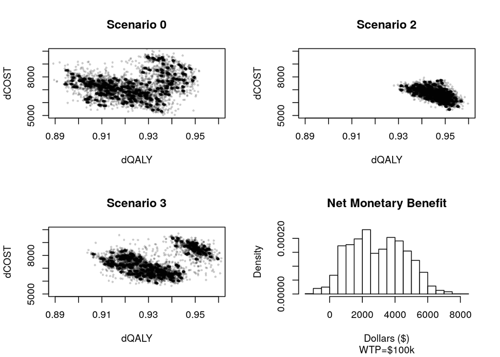

# Tornado Plots

These are made with the standard linear regression across factors.

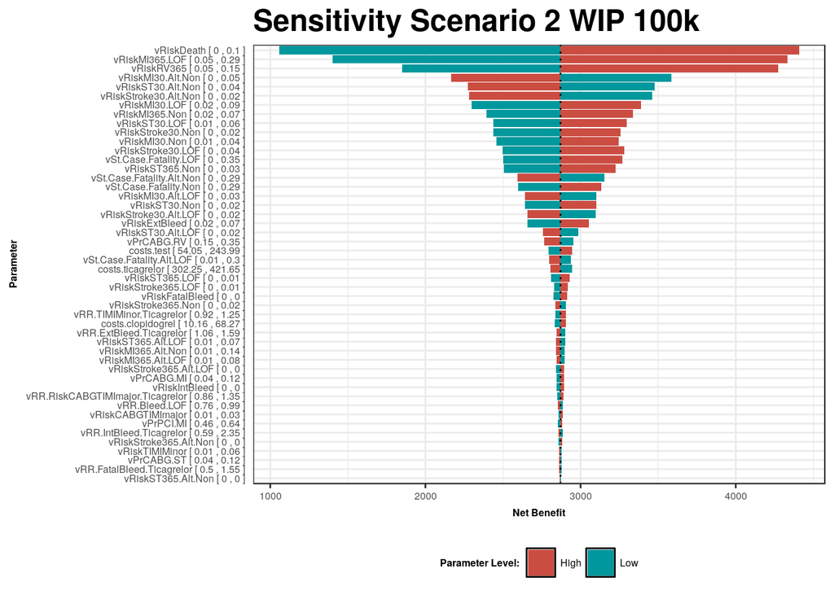

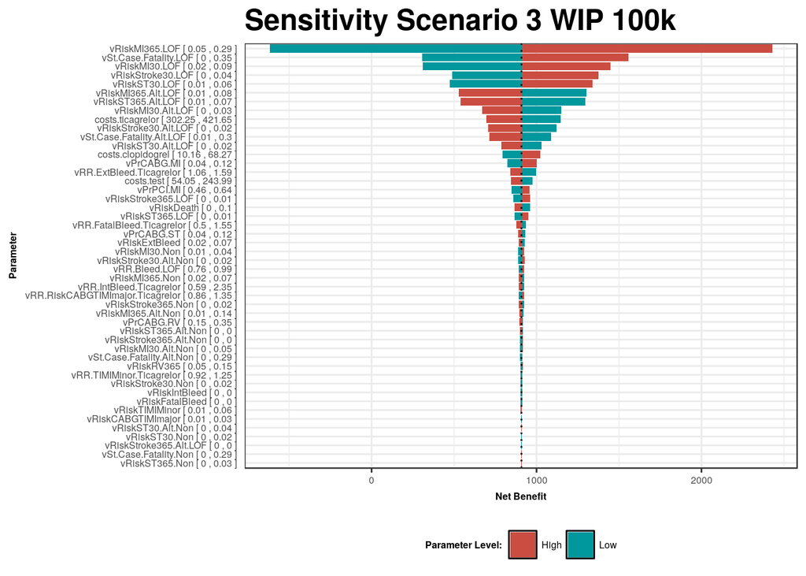

## Percent of Runs Greater than Zero

- 95.78% of scenario 2 net monetary benefits are greater than zero at a williness to pay threshold of $100k.
- 83.11% of scenario 3 net monetary benefits are greater than zero at a williness to pay threshold of $100k.
- 91.16% of scenario 2 net monetary benefits are greater than zero at a williness to pay threshold of $50k.
- 67.76% of scenario 3 net monetary benefits are greater than zero at a williness to pay threshold of $50k.

## Saltelli Method Results 100k WTP Scenario 2

Saltelli Ranking for Direct Contribution to Variance

| Variable | Single |
| --- | --- |
| vRiskDeath | 16.98 |
| vRiskStroke30.Alt.Non | 7.68 |
| vRiskMI30.Alt.Non | 5.07 |
| vRiskStroke30.LOF | 4.26 |
| vRiskST30.Alt.Non | 3.83 |
| vRiskStroke30.Non | 3.46 |
| vSt.Case.Fatality.LOF | 3.25 |
| vRiskMI365.LOF | 2.88 |
| vRiskStroke30.Alt.LOF | 2.65 |
| vRiskST30.LOF | 2.61 |
| vRiskExtBleed | 2.44 |
| vRiskMI30.LOF | 2.26 |
| vRiskMI30.Non | 2.04 |
| vRiskST365.Non | 1.83 |
| costs.ticagrelor | 1.76 |
| vRiskMI365.Non | 1.65 |
| costs.clopidogrel | 1.5 |
| vRiskMI365.Alt.Non | 1.48 |
| vPrCABG.ST | 1.46 |
| vRR.IntBleed.Ticagrelor | 1.41 |
| vRiskCABGTIMImajor | 1.35 |
| vRiskMI30.Alt.LOF | 1.34 |
| vRR.RiskCABGTIMImajor.Ticagrelor | 1.26 |
| vRiskST30.Non | 1.22 |
| vRiskStroke365.Non | 1.22 |
| vRiskStroke365.Alt.LOF | 1.19 |
| vRR.FatalBleed.Ticagrelor | 1.18 |
| vSt.Case.Fatality.Alt.Non | 1.16 |
| costs.test | 1.13 |
| vRR.TIMIMinor.Ticagrelor | 1.12 |
| vPrPCI.MI | 1.1 |
| vRiskRV365 | 1.1 |
| vRiskTIMIMinor | 1.08 |
| vRR.ExtBleed.Ticagrelor | 1.08 |
| vRiskST30.Alt.LOF | 1.05 |
| vRiskST365.LOF | 1.02 |
| vSt.Case.Fatality.Alt.LOF | 1 |
| vRiskStroke365.Alt.Non | 0.98 |
| vPrCABG.MI | 0.95 |
| vPrCABG.RV | 0.95 |
| vRR.Bleed.LOF | 0.93 |
| vRiskST365.Alt.LOF | 0.91 |
| vRiskIntBleed | 0.9 |
| vRiskST365.Alt.Non | 0.89 |
| vSt.Case.Fatality.Non | 0.87 |
| vRiskMI365.Alt.LOF | 0.85 |
| vRiskFatalBleed | 0.85 |
| vRiskStroke365.LOF | 0.81 |

Scaled to 100%

Saltelli Ranking Including All Interactions to Variance

| Variable | Total |
| --- | --- |
| vRiskDeath | 26.8 |
| vRiskStroke30.Alt.Non | 3.17 |
| vRiskST30.Non | 0 |
| vRiskST365.Non | 0 |
| vRiskST30.Alt.Non | 0 |
| vRiskST365.Alt.Non | 0 |
| vRiskST30.LOF | 0 |
| vRiskST365.LOF | 0 |
| vRiskST30.Alt.LOF | 0 |
| vRiskST365.Alt.LOF | 0 |
| vSt.Case.Fatality.Non | 0 |
| vSt.Case.Fatality.Alt.Non | 0 |
| vSt.Case.Fatality.LOF | 0 |
| vSt.Case.Fatality.Alt.LOF | 0 |
| vPrCABG.ST | 0 |
| vRiskMI30.Non | 0 |
| vRiskMI365.Non | 0 |
| vRiskMI30.Alt.Non | 0 |
| vRiskMI365.Alt.Non | 0 |
| vRiskMI30.LOF | 0 |
| vRiskMI365.LOF | 0 |
| vRiskMI30.Alt.LOF | 0 |
| vRiskMI365.Alt.LOF | 0 |
| vPrCABG.MI | 0 |
| vPrPCI.MI | 0 |
| vRiskStroke30.Non | 0 |
| vRiskStroke365.Non | 0 |
| vRiskStroke365.Alt.Non | 0 |
| vRiskStroke30.LOF | 0 |
| vRiskStroke365.LOF | 0 |
| vRiskStroke30.Alt.LOF | 0 |
| vRiskStroke365.Alt.LOF | 0 |
| vRiskRV365 | 0 |
| vPrCABG.RV | 0 |
| vRiskExtBleed | 0 |
| vRiskIntBleed | 0 |
| vRiskTIMIMinor | 0 |
| vRiskFatalBleed | 0 |
| vRR.ExtBleed.Ticagrelor | 0 |
| vRR.IntBleed.Ticagrelor | 0 |
| vRR.TIMIMinor.Ticagrelor | 0 |
| vRR.FatalBleed.Ticagrelor | 0 |
| vRiskCABGTIMImajor | 0 |
| vRR.RiskCABGTIMImajor.Ticagrelor | 0 |
| vRR.Bleed.LOF | 0 |
| costs.test | 0 |
| costs.clopidogrel | 0 |
| costs.ticagrelor | 0 |

## Saltelli Method Results 100k WTP Scenario 3

Saltelli Ranking for Direct Contribution to Variance

| Variable | Single |
| --- | --- |
| vRiskMI365.LOF | 46.83 |
| vRiskStroke30.LOF | 7.95 |
| vSt.Case.Fatality.LOF | 7.47 |
| vRiskST30.LOF | 7.06 |
| vRiskST365.Alt.LOF | 3.72 |
| costs.ticagrelor | 3.36 |
| vRiskMI365.Alt.LOF | 3.12 |
| vRiskStroke30.Alt.LOF | 2.33 |
| costs.clopidogrel | 1.97 |
| vPrPCI.MI | 1.53 |
| vRiskMI365.Alt.Non | 1.32 |
| vRR.IntBleed.Ticagrelor | 1.32 |
| vRR.RiskCABGTIMImajor.Ticagrelor | 1.05 |
| vSt.Case.Fatality.Non | 0.95 |
| vRR.TIMIMinor.Ticagrelor | 0.94 |
| vRiskMI30.Non | 0.8 |
| vRiskCABGTIMImajor | 0.73 |
| vRiskStroke365.Non | 0.57 |
| vPrCABG.ST | 0.55 |
| vRiskST30.Non | 0.51 |
| vRiskStroke30.Alt.Non | 0.49 |
| vRR.FatalBleed.Ticagrelor | 0.49 |
| vRiskST365.Alt.Non | 0.43 |
| vRiskStroke365.Alt.LOF | 0.42 |
| vRiskST365.Non | 0.41 |
| vRiskStroke30.Non | 0.41 |
| vRiskTIMIMinor | 0.4 |
| vRiskST365.LOF | 0.39 |
| vRiskST30.Alt.Non | 0.34 |
| vRR.ExtBleed.Ticagrelor | 0.31 |
| vPrCABG.RV | 0.29 |
| costs.test | 0.29 |
| vRiskStroke365.Alt.Non | 0.27 |
| vRiskExtBleed | 0.24 |
| vRiskFatalBleed | 0.22 |
| vRiskMI30.Alt.Non | 0.21 |
| vRiskST30.Alt.LOF | 0.2 |
| vSt.Case.Fatality.Alt.Non | 0.05 |
| vRiskStroke365.LOF | 0.04 |
| vRiskIntBleed | 0.03 |
| vSt.Case.Fatality.Alt.LOF | 0 |
| vRiskMI365.Non | 0 |
| vRiskMI30.LOF | 0 |
| vRiskMI30.Alt.LOF | 0 |
| vPrCABG.MI | 0 |
| vRiskDeath | 0 |
| vRiskRV365 | 0 |
| vRR.Bleed.LOF | 0 |

Scaled to 100%

Saltelli Ranking Including All Interactions to Variance

| Variable | Total |
| --- | --- |
| vRiskMI365.LOF | 67.14 |
| vRiskStroke30.LOF | 17.88 |
| vRiskST30.LOF | 16.58 |
| vRiskMI365.Alt.LOF | 10.21 |
| vRiskST365.Alt.LOF | 9.31 |
| costs.ticagrelor | 9.08 |
| vSt.Case.Fatality.LOF | 7.54 |
| vRiskStroke30.Alt.LOF | 7.52 |
| costs.clopidogrel | 6.19 |
| vRiskST365.Non | 5.34 |
| vRiskStroke365.LOF | 5.3 |
| vPrCABG.RV | 5.19 |
| costs.test | 5.16 |
| vRiskStroke365.Alt.LOF | 5.14 |
| vRiskTIMIMinor | 5.14 |
| vRiskST30.Alt.Non | 5.12 |
| vRiskStroke365.Non | 5.05 |
| vRiskStroke365.Alt.Non | 5.01 |
| vRiskMI365.Non | 4.99 |
| vRiskMI30.Alt.Non | 4.94 |
| vRiskDeath | 4.7 |
| vRiskST365.LOF | 4.69 |
| vRiskST365.Alt.Non | 4.63 |
| vRiskST30.Alt.LOF | 4.63 |
| vRR.RiskCABGTIMImajor.Ticagrelor | 4.6 |
| vRiskRV365 | 4.49 |
| vRiskIntBleed | 4.44 |
| vRiskExtBleed | 4.4 |
| vRR.ExtBleed.Ticagrelor | 4.38 |
| vSt.Case.Fatality.Non | 4.31 |
| vRiskStroke30.Non | 4.26 |
| vPrPCI.MI | 4.23 |
| vRiskFatalBleed | 4.22 |
| vPrCABG.ST | 4.19 |
| vRiskStroke30.Alt.Non | 3.98 |
| vRiskST30.Non | 3.93 |
| vRR.FatalBleed.Ticagrelor | 3.93 |
| vRiskCABGTIMImajor | 3.91 |
| vRiskMI30.Non | 3.88 |
| vRR.Bleed.LOF | 3.81 |
| vRiskMI365.Alt.Non | 3.57 |
| vPrCABG.MI | 3.52 |
| vSt.Case.Fatality.Alt.Non | 3.49 |
| vRR.TIMIMinor.Ticagrelor | 3.49 |
| vSt.Case.Fatality.Alt.LOF | 2.91 |
| vRiskMI30.Alt.LOF | 2.78 |
| vRR.IntBleed.Ticagrelor | 2.3 |
| vRiskMI30.LOF | 0 |

Total exceeds 100% since variance contribution occurs in multiple terms via interaction